# 17.Student Distribution

If the normal distribution is to populations, then the Student distribution is to samples. The student distribution was first discovered by [William Sealy Gosset](https://en.wikipedia.org/wiki/William_Sealy_Gosset) in 1908. Recall that the normal distribution applies to a population and may be described by the population's mean and standard deviation. It can be imagined that if a sample of a population is collected, then the sample mean may differ from the population mean. It can also be imagined that different samples from the same population could produce different means. The same applies to the standard deviation. A particular sample from a population will likely not have the same standard deviation, and different samples from the same population will likely not result in the same standard deviation. So if the sample mean and standard deviation are not a good estimate of the population mean and standard deviation, then the sample mean and standard deviation should not be used in the normal distribution as it will likely lead to erroneous results. The Student distribution is then used in these cases. The Student distribution may be thought of as the best guess of the population's normal distribution when a sample is collected. It applies to a continuous random variable just like the normal distribution, and there is an equal likelihood of positive and negative values. It is reasonable to say that a sample with twenty data points is likely a better picture of the parent population than a sample with only ten data points. The more data that is collected, the better the parent population is understood. Another way to say that is the Student distribution approaches that of the normal distribution as the number of data points in the sample increases. The Student distribution depends on two parameters, the continuous random variable $ t $ and the degrees of freedom $ \nu $. The degrees of freedom of the distribution is given by

$$ \nu = n - 1 $$

where $ n $ is the number of data points in the sample. Without going into too much detail, the term degrees of freedom is often used in statistics. It refers to the number of parameters in a collection that are allowed to vary. The probability density function (PDF) for a Student distribution is given by

$$ P\left(t, \nu \right) = \frac{\Gamma \left( \frac{\nu + 1}{2} \right)}{\sqrt{\nu \pi}\left(\frac{\nu}{2}\right)\left(1+\frac{t^2}{\nu}\right)^\frac{\nu+1}{2}} $$

where the $ \Gamma \left(\ldots \right) $ function is the Gamma function and is given by

$$ \Gamma \left( x \right) = \left(x - 1\right)! $$

The PDF of the Student distribution is shown below in Figure 1.

Figure 1: Student distribution

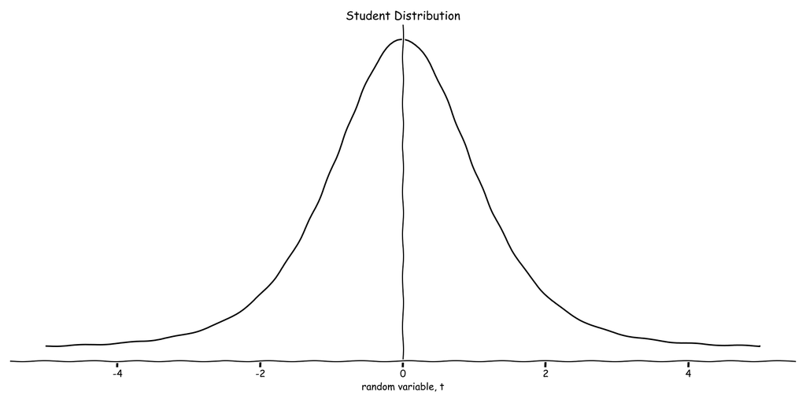

The Student distribution has the familiar bell shape and resembles that of the normal distribution, but it is different. The differences will be seen in the example problem below. Just like with the normal distribution, calculating the Student distribution values using the PDF would be impractical. Fortunately, a tabulated version of the Student distribution is widely available. The Student distribution is shown below in Table 1.

Table 1: Student Distribution

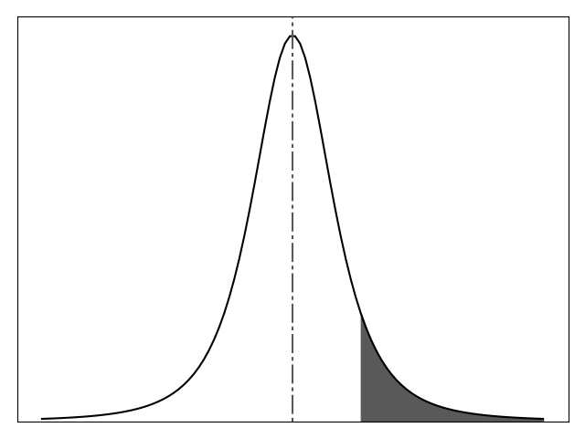

|  |  |  |  |  | $\frac{\alpha}{2}$ |  |  |  |  |
| --- | --- | --- | --- | --- | --- | --- | --- | --- | --- |
| $\nu$ | 0.25 | 0.2 | 0.1 | 0.05 | 0.025 | 0.02 | 0.01 | 0.005 | 0.001 |
| 1 | 1.000 | 1.376 | 3.078 | 6.314 | 12.706 | 15.895 | 31.821 | 63.657 | 318.309 |
| 2 | 0.816 | 1.061 | 1.886 | 2.920 | 4.303 | 4.849 | 6.965 | 9.925 | 22.327 |
| 3 | 0.765 | 0.978 | 1.638 | 2.353 | 3.182 | 3.482 | 4.541 | 5.841 | 10.215 |
| 4 | 0.741 | 0.941 | 1.533 | 2.132 | 2.776 | 2.999 | 3.747 | 4.604 | 7.173 |
| 5 | 0.727 | 0.920 | 1.476 | 2.015 | 2.571 | 2.757 | 3.365 | 4.032 | 5.893 |
| 6 | 0.718 | 0.906 | 1.440 | 1.943 | 2.447 | 2.612 | 3.143 | 3.707 | 5.208 |
| 7 | 0.711 | 0.896 | 1.415 | 1.895 | 2.365 | 2.517 | 2.998 | 3.499 | 4.785 |
| 8 | 0.706 | 0.889 | 1.397 | 1.860 | 2.306 | 2.449 | 2.896 | 3.355 | 4.501 |
| 9 | 0.703 | 0.883 | 1.383 | 1.833 | 2.262 | 2.398 | 2.821 | 3.250 | 4.297 |
| 10 | 0.700 | 0.879 | 1.372 | 1.812 | 2.228 | 2.359 | 2.764 | 3.169 | 4.144 |
| 11 | 0.697 | 0.876 | 1.363 | 1.796 | 2.201 | 2.328 | 2.718 | 3.106 | 4.025 |
| 12 | 0.695 | 0.873 | 1.356 | 1.782 | 2.179 | 2.303 | 2.681 | 3.055 | 3.930 |
| 13 | 0.694 | 0.870 | 1.350 | 1.771 | 2.160 | 2.282 | 2.650 | 3.012 | 3.852 |
| 14 | 0.692 | 0.868 | 1.345 | 1.761 | 2.145 | 2.264 | 2.624 | 2.977 | 3.787 |
| 15 | 0.691 | 0.866 | 1.341 | 1.753 | 2.131 | 2.249 | 2.602 | 2.947 | 3.733 |
| 16 | 0.690 | 0.865 | 1.337 | 1.746 | 2.120 | 2.235 | 2.583 | 2.921 | 3.686 |
| 17 | 0.689 | 0.863 | 1.333 | 1.740 | 2.110 | 2.224 | 2.567 | 2.898 | 3.646 |
| 18 | 0.688 | 0.862 | 1.330 | 1.734 | 2.101 | 2.214 | 2.552 | 2.878 | 3.610 |
| 19 | 0.688 | 0.861 | 1.328 | 1.729 | 2.093 | 2.205 | 2.539 | 2.861 | 3.579 |
| 20 | 0.687 | 0.860 | 1.325 | 1.725 | 2.086 | 2.197 | 2.528 | 2.845 | 3.552 |
| 21 | 0.686 | 0.859 | 1.323 | 1.721 | 2.080 | 2.189 | 2.518 | 2.831 | 3.527 |
| 22 | 0.686 | 0.858 | 1.321 | 1.717 | 2.074 | 2.183 | 2.508 | 2.819 | 3.505 |
| 23 | 0.685 | 0.858 | 1.319 | 1.714 | 2.069 | 2.177 | 2.500 | 2.807 | 3.485 |
| 24 | 0.685 | 0.857 | 1.318 | 1.711 | 2.064 | 2.172 | 2.492 | 2.797 | 3.467 |
| 25 | 0.684 | 0.856 | 1.316 | 1.708 | 2.060 | 2.167 | 2.485 | 2.787 | 3.450 |
| 26 | 0.684 | 0.856 | 1.315 | 1.706 | 2.056 | 2.162 | 2.479 | 2.779 | 3.435 |
| 27 | 0.684 | 0.855 | 1.314 | 1.703 | 2.052 | 2.158 | 2.473 | 2.771 | 3.421 |
| 28 | 0.683 | 0.855 | 1.313 | 1.701 | 2.048 | 2.154 | 2.467 | 2.763 | 3.408 |
| 29 | 0.683 | 0.854 | 1.311 | 1.699 | 2.045 | 2.150 | 2.462 | 2.756 | 3.396 |
| 30 | 0.683 | 0.854 | 1.310 | 1.697 | 2.042 | 2.147 | 2.457 | 2.750 | 3.385 |
| 31 | 0.682 | 0.853 | 1.309 | 1.696 | 2.040 | 2.144 | 2.453 | 2.744 | 3.375 |
| 32 | 0.682 | 0.853 | 1.309 | 1.694 | 2.037 | 2.141 | 2.449 | 2.738 | 3.365 |
| 33 | 0.682 | 0.853 | 1.308 | 1.692 | 2.035 | 2.138 | 2.445 | 2.733 | 3.356 |
| 34 | 0.682 | 0.852 | 1.307 | 1.691 | 2.032 | 2.136 | 2.441 | 2.728 | 3.348 |
| 35 | 0.682 | 0.852 | 1.306 | 1.690 | 2.030 | 2.133 | 2.438 | 2.724 | 3.340 |
| $\infty$ | 0.674 | 0.842 | 1.282 | 1.645 | 1.960 | 2.054 | 2.326 | 2.576 | 3.090 |

There are a couple of things to note about the Student distribution table. First is the $ \frac{\alpha}{2} $ term on the top of the table. $ \alpha $ is known as the level of significance. $\frac{\alpha}{2} $ is the shaded area of the diagram, and it's values are the first row of the table (i.e., $0.25$, $0.2$, $0.1$, etc.). Secondly, the degrees of freedom $\nu$ values are shown in the first column. They start at $ 1 $ and go to $35$. There is also an additional row at the bottom that begins with $\infty$. This row would represent the case if an infinite number of data points were collected for a sample. As previously mentioned, the Student distribution approaches that of the normal distribution as the number of data points in a sample increases. Since the degrees of freedom $ \nu $ is just the number of data points in a sample minus one, the same can be said of the degrees of freedom of the Student distribution. The Student distribution approaches that of the normal distribution as the number of degrees of freedom increases. This last row in Table 1 therefore, actually represents the normal distribution perfectly. If you compare the last row of Table 1 to the standard normal distribution table, the values will be identical. The values represented in the middle section of Table 1 are the particular $ t $ values. This arrangement is somewhat opposite of how the standard normal distribution table is setup. In the standard normal distribution table, the table's middle section is the probabilities $ P $ (the shaded area). The first column and row are the random variable $ z $ values. In the Student distribution table, the first row is the probabilities $ \frac{\alpha}{2} $, and the middle section is the random variable $ t $ values.

## Example

**Given and Required:**

1. If the number of data points collected in a sample is $25$, what is the $t$ value for a level of significance of $0.05$?
2. If the number of data points collected in a sample is $15$, what is the level of significance if the $ t $ value is $1.56$?
3. Plot the Student distribution for degrees of freedom of $2$, $7$, $16$, and $30$. On the same plot, plot the standard normal distribution.

**Solution:**

The given number of data points and level of significance for part (a) are defined as

```python
n1 = 25
alpha1 = 0.05
```

The given number of data points and the $ t $ value for part (b) are defined as

```python
n2 = 15
t2 = 1.56
```

The given degrees of freedom for part (c) are defined as

```python
nu = [2, 7, 16, 30]
```

At this point, any needed libraries may be imported.

```python
import matplotlib.pyplot as plt
import numpy as np
import scipy.stats as sp
```

For part (a), the solution will be found by first using the Student distribution table and then using Python. To begin, the degrees of freedom $ \nu_{\left(a\right)} $ must first be found. The degrees of freedom is shown below.

$$ \nu_{\left(a\right)} = n_1 - 1 = 25 - 1 = 24 $$

Half of the level of significance is then determined below.

$$ \left(\frac{\alpha}{2}\right)_{\left(a\right)} = \frac{\alpha_1}{2} = \frac{0.05}{2} = 0.025 $$

Now that both the degrees of freedom $ \nu_{\left(a\right)} $ and half of the level of significance is known, Table 1 may be used. The degrees of freedom of $ 24 $ row is found using the first column. Then looking at the first row, the column with half of the level of significance of $ 0.025 $ is found. The intersection of the degrees of freedom row and half of the level of significance column is then the desired $ t $ value. Doing so yields $ 2.064 $.

Part (a): The $ t $ value for a level of significance of $ 0.05 $ and data set of size $ 25 $ is $ 2.064 $.

The degrees of freedom may be found by using Python.

```python
nu1 = n1 - 1
print(nu1)
```

```
24
```

Half the level of significance is then calculated.

```python
alpha1_2 = alpha1/2
print(alpha1_2)
```

```
0.025
```

Now a Student distribution handle may be created.

```python
tDist_a = sp.t(nu1)
```

Since the $ t $ value is desired, the inverse cumulative distribution function or percentage point function (PPF) will be used.

```python
print(tDist_a.ppf(1 - alpha1_2)) # Answer to part (a)
```

```
2.0638985616280205
```

Note the `ppf` function is given one minus half the level of significance. This operation is conducted because the `ppf` function expects the Student distribution's unshaded region, as depicted by the diagram shown in Table 1.

For part (b), a similar process is used as part (a) but only in reverse. To begin, the degrees of freedom $ \nu_{\left(b\right)} $ is determined below.

$$ \nu_{\left(b\right)} = n_2 - 1 = 15 - 1 = 14 $$

A subsection of Table 1 is shown below to aid the solution.

|  |  |  |  |  | $\frac{\alpha}{2}$ |  |  |  |  |
| --- | --- | --- | --- | --- | --- | --- | --- | --- | --- |
| $\nu$ | 0.25 | 0.2 | 0.1 | 0.05 | 0.025 | 0.02 | 0.01 | 0.005 | 0.001 |
| 1 | 1.000 | 1.376 | 3.078 | 6.314 | 12.706 | 15.895 | 31.821 | 63.657 | 318.309 |
| 2 | 0.816 | 1.061 | 1.886 | 2.920 | 4.303 | 4.849 | 6.965 | 9.925 | 22.327 |
| $\vdots$ | $\vdots$ | $\vdots$ | $\vdots$ | $\vdots$ | $\vdots$ | $\vdots$ | $\vdots$ | $\vdots$ | $\vdots$ |
| 13 | 0.694 | 0.870 | 1.350 | 1.771 | 2.160 | 2.282 | 2.650 | 3.012 | 3.852 |
| 14 | 0.692 | 0.868 | 1.345 | 1.761 | 2.145 | 2.264 | 2.624 | 2.977 | 3.787 |
| 15 | 0.691 | 0.866 | 1.341 | 1.753 | 2.131 | 2.249 | 2.602 | 2.947 | 3.733 |

Using the row that begins with $ 14 $, a $ t $ value of $ 1.56 $ falls between the $ 0.1 $ and $ 0.05 $ column. Since the $ t $ value did not fall exactly on a column, interpolation must be used. This is shown below.

$$ \left(\frac{\alpha}{2}\right)_\left(b\right) = \left(\frac{1.56 - 1.345}{1.761 - 1.345}\right)\left( 0.05 - 0.1\right) + 0.1 = 0.07416 $$

The level of significance $ \alpha_{\left(b\right)} $ is now twice this number.

$$ \alpha_{\left(b\right)} = 2 \left(\frac{\alpha}{2}\right)_{\left(b\right)} = 2 \left(0.07416\right) = 0.1483$$

Part (b): The level of significance for a $ t $ value of $1.56$ and data set of size $ 15 $ is $ 0.1483$.

The degrees of freedom may first be calculated to solve part (b) in Python.

```python
nu2 = n2 - 1
print(nu2)
```

```
14
```

Now a Student distribution handle may be created.

```python
tDist_b = sp.t(nu2)
```

Since the level of significance is desired, the CDF is used to determine the level of significance.

```python
alpha2 = 2*(1 - tDist_b.cdf(t2))
print(alpha2) # Answer to part (b)
```

```
0.14107440546692063
```

It should be noted that the value doesn't match what was previously found precisely. The difference is due to the interpolation used in the method involving the table.

For part (c), a range of x-axis values will first be created using NumPy's `linspace` function.

```python
x = np.linspace(-5, 5, 100)
print(x)
```

```
[-5.         -4.8989899  -4.7979798  -4.6969697  -4.5959596  -4.49494949
 -4.39393939 -4.29292929 -4.19191919 -4.09090909 -3.98989899 -3.88888889
 -3.78787879 -3.68686869 -3.58585859 -3.48484848 -3.38383838 -3.28282828
 -3.18181818 -3.08080808 -2.97979798 -2.87878788 -2.77777778 -2.67676768
 -2.57575758 -2.47474747 -2.37373737 -2.27272727 -2.17171717 -2.07070707
 -1.96969697 -1.86868687 -1.76767677 -1.66666667 -1.56565657 -1.46464646
 -1.36363636 -1.26262626 -1.16161616 -1.06060606 -0.95959596 -0.85858586
 -0.75757576 -0.65656566 -0.55555556 -0.45454545 -0.35353535 -0.25252525
 -0.15151515 -0.05050505  0.05050505  0.15151515  0.25252525  0.35353535
  0.45454545  0.55555556  0.65656566  0.75757576  0.85858586  0.95959596
  1.06060606  1.16161616  1.26262626  1.36363636  1.46464646  1.56565657
  1.66666667  1.76767677  1.86868687  1.96969697  2.07070707  2.17171717
  2.27272727  2.37373737  2.47474747  2.57575758  2.67676768  2.77777778
  2.87878788  2.97979798  3.08080808  3.18181818  3.28282828  3.38383838
  3.48484848  3.58585859  3.68686869  3.78787879  3.88888889  3.98989899
  4.09090909  4.19191919  4.29292929  4.39393939  4.49494949  4.5959596
  4.6969697   4.7979798   4.8989899   5.        ]
```

The various Student distribution handles may then be created using the given degrees of freedom.

```python
tDist1 = sp.t(nu[0])
tDist2 = sp.t(nu[1])
tDist3 = sp.t(nu[2])
tDist4 = sp.t(nu[3])
```

The standard normal distribution is also created.

```python
nDist = sp.norm(0, 1)
```

The plot may now be created.

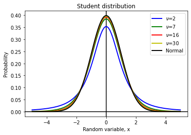

```python
fig, ax = plt.subplots(1, 1)

ax.set_title('Student distribution')
ax.set_xlabel('Random variable, x')
ax.set_ylabel('Probability')
ax.axhline(color='k')
ax.axvline(color='k')

ax.plot(x, tDist1.pdf(x), 'b-', lw=2, label='$\\nu$='+str(nu[0]))
ax.plot(x, tDist2.pdf(x), 'g-', lw=2, label='$\\nu$='+str(nu[1]))
ax.plot(x, tDist3.pdf(x), 'r-', lw=2, label='$\\nu$='+str(nu[2]))
ax.plot(x, tDist4.pdf(x), 'y-', lw=2, label='$\\nu$='+str(nu[3]))

ax.plot(x, nDist.pdf(x), 'k-', lw=2, label='Normal')

ax.legend(loc='best')
plt.show()
```

As the degrees of freedom increase, the Student distribution gets closer to the normal distribution.

Download Complete Python Script Here